# Lab 4: t-test Assumptions and Transformations

ST 411/511: Methods of Data Analysis I

## Notes

- Remember that you can click “Preview Notebook” to view this document in the Viewer pane. This may be helpful because math notation that I write between “$” will appear formatted correctly.

## Outline

In today’s lab, we will

- Learn a little more R functionality
- See how to add new variables to a data frame
- See how to examine assumptions of the $t$-test
- See how to do a simulation study for confidence intervals

## Some additional R functionality

So far, we’ve been dealing with existing datasets that come in the form of *data.frames* and that are available in the `Sleuth3` library. As you’ve seen a *data.frame* is a specific type of R object – it’s a rectangular array of data, where the rows contain observations on different subjects (or sampling units or experimental units), and the columns contain different variables that are measured and/or recorded on those subjects.

Remember you can use `?` to pop up the help file for a data set or function in the help pane, which can be useful for seeing column names or function arguments. The `head()` function will print out the first 6 rows of data, which can be useful for getting a sense of the data and viewing the column names. We can look at the number of rows and columns in a data frame by using the `dim()` function, where the output is the number of rows, then the number of columns.

```r
print(getwd())
```

```
[1] "/Users/chikezic/Desktop/OSU/ST411511/Homework/Report"
```

```r
gend <- read.csv("/Users/chikezic/Desktop/OSU/ST411511/Homework/Report/gen_data.csv")
dim(gend)
```

```
[1] 266782      8
```

```r
ProjectA <- read.csv("/Users/chikezic/Desktop/OSU/ST411511/Homework/Report/Cholesterol_projectA.csv")
ProjectB <- read.csv("/Users/chikezic/Desktop/OSU/ST411511/Homework/Report/Cholesterol_projectB.csv")
View(ProjectA)
View(ProjectB)
```

$H_0: \mu_D = 0$ $H_A: \mu_D > 0$

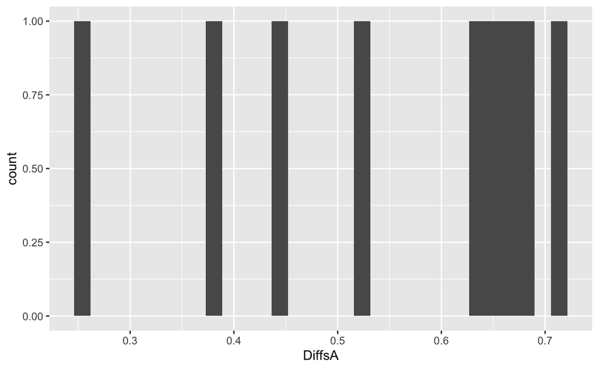

```r
ggplot(ProjectA, aes(x = DiffsA)) +
  geom_histogram()
```

```r
DiffsA <- ProjectA$Before - ProjectA$After8weeks
m <- median(DiffsA)
m
```

```
[1] 0.63
```

```r
nDiffsA <- length(DiffsA)
nDiffsA
```

```
[1] 9
```

```r
Kstat <- sum(DiffsA > 0)
Kstat
```

```
[1] 9
```

```r
binom.test(Kstat, n=nDiffsA, p=0.5, alt="greater")
```

```
    Exact binomial test

data:  Kstat and nDiffsA
number of successes = 9, number of trials = 9, p-value = 0.001953
alternative hypothesis: true probability of success is greater than 0.5
95 percent confidence interval:
 0.7168712 1.0000000
sample estimates:
probability of success
                     1
```